# Foundation of Data Analytics

J-Component-Review3

SAMARTH SINHA(19BCE1670),KUNAL SUDHIR MISHRA(19BCE1447)

12/12/2021

##load the dataset from csv file

```r
data<-read.csv("C:/Users/User/Downloads/archive (1)/globalterrorismdb_0718dist.csv")
head(data)
```

```
##       eventid iyear imonth iday approxdate extended resolution country
## 1 1.97000e+11  1970      7    2                   0                 58
## 2 1.97000e+11  1970      0    0                   0                130
## 3 1.97001e+11  1970      1    0                   0                160
## 4 1.97001e+11  1970      1    0                   0                 78
## 5 1.97001e+11  1970      1    0                   0                101
## 6 1.97001e+11  1970      1    1                   0                217
##          country_txt region                  region_txt provstate          city
## 1 Dominican Republic      2 Central America & Caribbean           Santo Domingo
## 2             Mexico      1               North America   Federal   Mexico city
## 3        Philippines      5              Southeast Asia    Tarlac       Unknown
## 4             Greece      8              Western Europe    Attica        Athens
## 5              Japan      4                   East Asia   Fukouka       Fukouka
## 6      United States      1               North America  Illinois         Cairo
##   latitude longitude specificity vicinity location
```

[output cut: 195 more lines]

##use ts() function to place in time-series format

```r
library(timeSeries)
library(forecast)
class(data)
```

```
## [1] "data.frame"
```

```r
ts (data, frequency = 4, start = c(1959, 2))
```

```
##              eventid iyear imonth iday approxdate extended resolution country
##  1959 Q2 1.97000e+11  1970      7    2          1        0          1      58
##  1959 Q3 1.97000e+11  1970      0    0          1        0          1     130
##  1959 Q4 1.97001e+11  1970      1    0          1        0          1     160
##  1960 Q1 1.97001e+11  1970      1    0          1        0          1      78
##  1960 Q2 1.97001e+11  1970      1    0          1        0          1     101
##  1960 Q3 1.97001e+11  1970      1    1          1        0          1     217
##  1960 Q4 1.97001e+11  1970      1    2          1        0          1     218
##  1961 Q1 1.97001e+11  1970      1    2          1        0          1     217
##  1961 Q2 1.97001e+11  1970      1    2          1        0          1     217
##  1961 Q3 1.97001e+11  1970      1    3          1        0          1     217
##  1961 Q4 1.97001e+11  1970      1    1          1        0          1     217
##  1962 Q1 1.97001e+11  1970      1    6          1        0          1     217
##  1962 Q2 1.97001e+11  1970      1    8          1        0          1      98
##  1962 Q3 1.97001e+11  1970      1    9          1        0          1     217
```

[output cut: 16288 more lines]

```r
ts (1:10, frequency = 12, start = 1990)
```

```
##      Jan Feb Mar Apr May Jun Jul Aug Sep Oct
## 1990   1   2   3   4   5   6   7   8   9  10
```

```r
tsData = ts(data$nkill, start = c(2011,1), frequency = 52)
tsData
```

```
## Time Series:
## Start = c(2011, 1)
## End = c(5505, 3)
## Frequency = 52
##     [1]    1    0    1   NA   NA    0    0    0    0    0    0    0    0    0
##    [15]    0   NA    1    0    0    0    0    0    0    0    0    1    0    0
##    [29]    0    0    0    0    0    0   NA    0    0    0    0    0    0    0
##    [43]    0    0    0    0    0    0    0    0    0    0    0    0    0    0
##    [57]    0    0    0    1    0    0    7    0    0    0    1    0    0    0
##    [71]    0    0    0    0    0    0    0    0    0    0   47    0    0    0
##    [85]    0    0    0    0    0    0    0    0    0    0    0   NA    0    0
##    [99]    0    0    0    0    0    0    0    0    0    0    0    0    0    2
##   [113]    0    0    0    0    0    0    0    2    0    0    0    0    0    0
##   [127]    0    0    0    0    0    0    0    0    0    0    0    0    0    0
##   [141]    0    0    1    0    0    0    0    0    0    0    1    0    0    0
```

[output cut: 7133 more lines]

##use timeseries formatted data

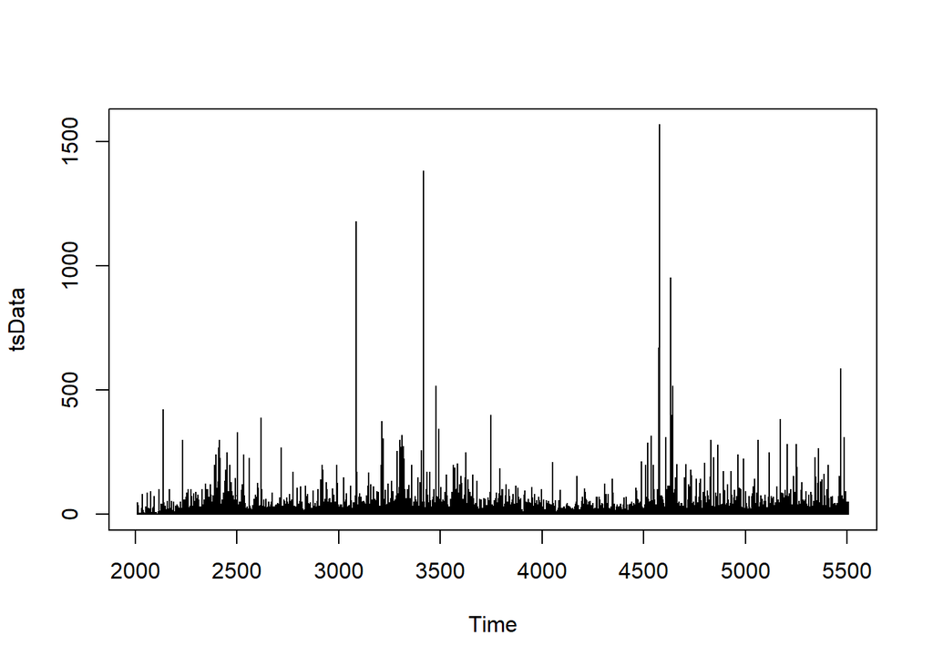

```r
plot(tsData)
```

##use auto.arima() function to get the optimal auto arima model

```r
autoarima1<-auto.arima(tsData)
forecast1<-forecast(autoarima1,h=17)
forecast1
```

```
##          Point Forecast     Lo 80    Hi 80     Lo 95    Hi 95
## 5505.058      0.4073690 -15.26920 16.08394 -23.56787 24.38261
## 5505.077      0.5496574 -15.76305 16.86237 -24.39848 25.49779
## 5505.096      0.5386574 -16.15802 17.23534 -24.99671 26.07403
## 5505.115      0.2895200 -16.83407 17.41311 -25.89875 26.47779
## 5505.135      0.2908397 -17.37594 17.95762 -26.72817 27.30985
## 5505.154      0.3284175 -18.03854 18.69537 -27.76142 28.41825
## 5505.173      0.3890142 -18.99783 19.77586 -29.26060 30.03863
## 5505.192      0.3996163 -19.57851 20.37774 -30.15429 30.95352
## 5505.212      0.3810827 -20.12954 20.89170 -30.98721 31.74937
## 5505.231      0.3506982 -20.70428 21.40568 -31.85012 32.55152
## 5505.250      0.3542605 -21.26713 21.97565 -32.71280 33.42132
## 5505.269      0.3641023 -21.83604 22.56424 -33.58808 34.31628
## 5505.288      0.3720011 -22.40350 23.14750 -34.46012 35.20412
## 5505.308      0.3712398 -22.92734 23.66982 -35.26086 36.00334
## 5505.327      0.3668707 -23.43925 24.17299 -36.04145 36.77519
## 5505.346      0.3635067 -23.94598 24.67299 -36.81464 37.54165
## 5505.365      0.3647871 -24.44403 25.17360 -37.57702 38.30659
```

##plot forcasted data from auto-arima model

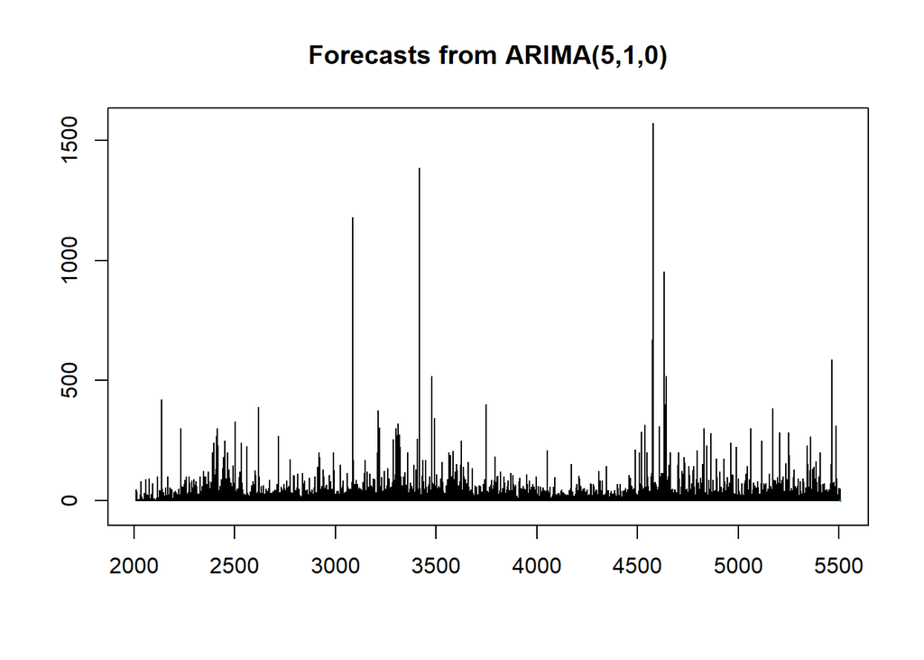

```r
plot(forecast1)
```

##plot residual over time to see variance

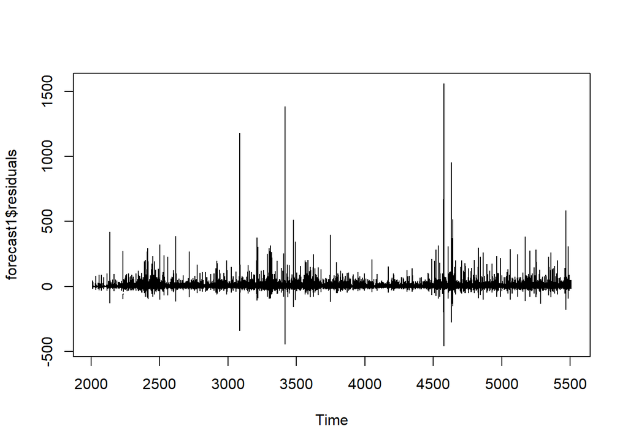

```r
plot(forecast1$residuals)
```

##plot the residual(sample vs theoritical)

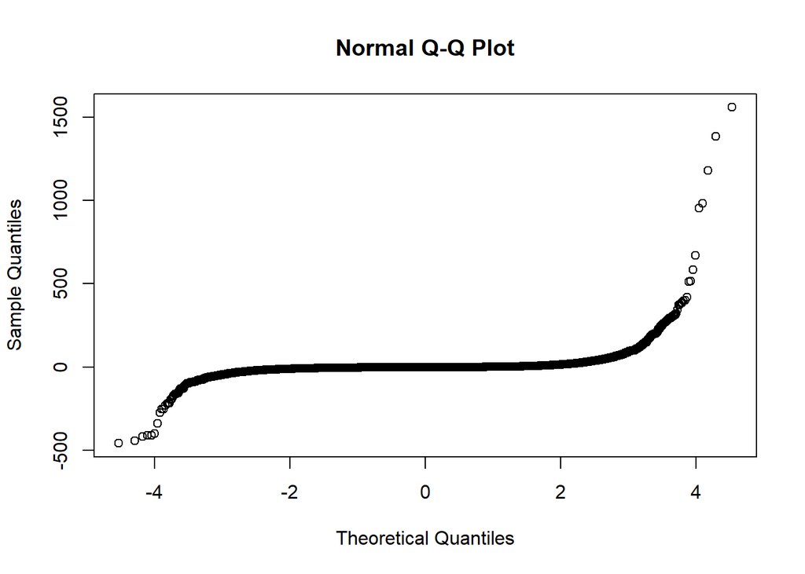

```r
qqnorm(forecast1$residuals)
```

##acf & pacf

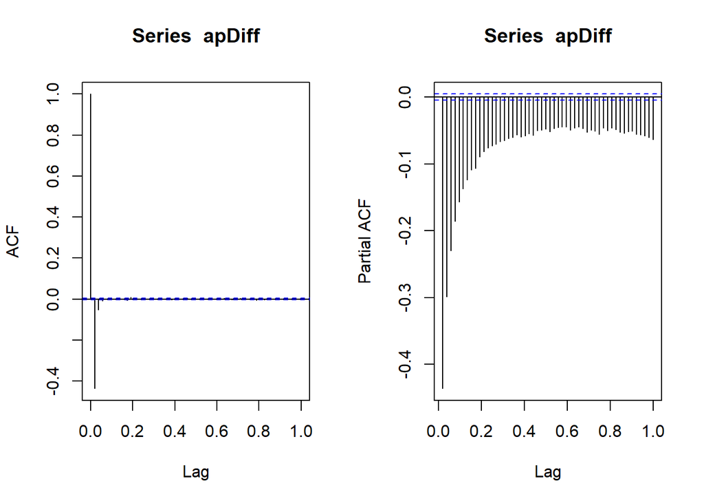

```r
apNum = as.numeric(tsData)
apDiff = diff(tsData, differences = 1)
op = par(mfrow=c(1,2))
acf(apDiff, plot = T,na.action = na.pass)
pacf(apDiff, plot = T,na.action = na.pass)
```

```r
par(op)
```

##get accuracy by MAPE and other leading indicators - each dataset is different ##method1

```r
summary(autoarima1)
```

```
## Series: tsData
## ARIMA(5,1,0)
##
## Coefficients:
##           ar1      ar2      ar3      ar4      ar5
##       -0.7122  -0.5679  -0.4324  -0.2966  -0.1609
## s.e.   0.0025   0.0029   0.0030   0.0029   0.0024
##
## sigma^2 estimated as 149.6:  log likelihood=-673102.3
## AIC=1346217   AICc=1346217   BIC=1346277
##
## Training set error measures:
##                        ME     RMSE      MAE MPE MAPE      MASE        ACF1
## Training set -0.001351827 12.23228 3.277314 NaN  Inf 0.8429262 -0.01741859
```

##get accuracy by MAPE and other leading indicators - each dataset is different. ##method2

```r
accuracy(autoarima1)
```

```
##                        ME     RMSE      MAE MPE MAPE      MASE        ACF1
## Training set -0.001351827 12.23228 3.277314 NaN  Inf 0.8429262 -0.01741859
```

```r
data.train<-window(tsData,end=2020)
data.test<-window(tsData,end=2020)
```

```r
meann<-meanf(data.train,h=30)
naivem<-naive(data.train,h=30)
driftm<-rwf(data.train,h=30)
snaivem<-snaive(data.train,h=30)
```

##visualisation for all method

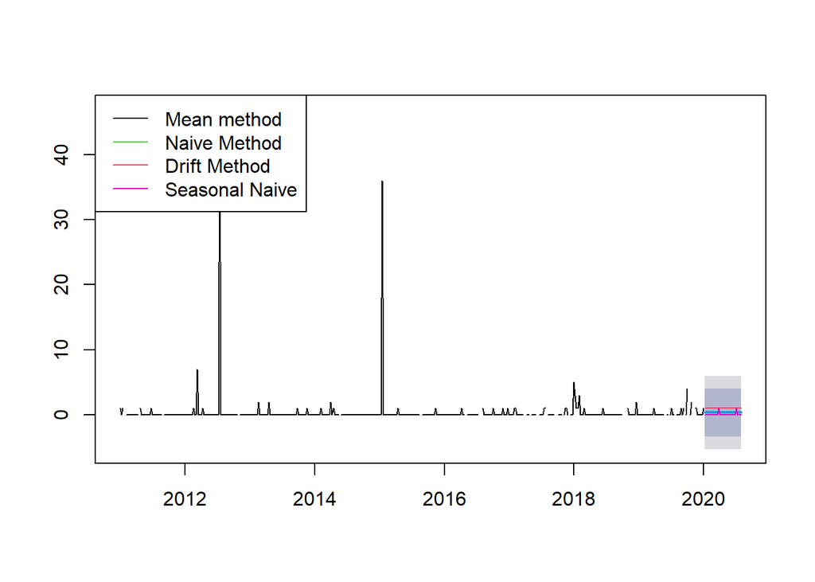

```r
plot(meann,plot.conf=F,main="")
lines(naivem$mean,col=3,lty=1)
lines(driftm$mean,col=2,lty=1)
lines(snaivem$mean,col=6,lty=1)
legend("topleft",lty=1,col=c(1,3,2,6),legend=c("Mean method","Naive Method","Drift Method","Seasonal Naive"))
```

##forecasted data for arima-model for suicide attributes

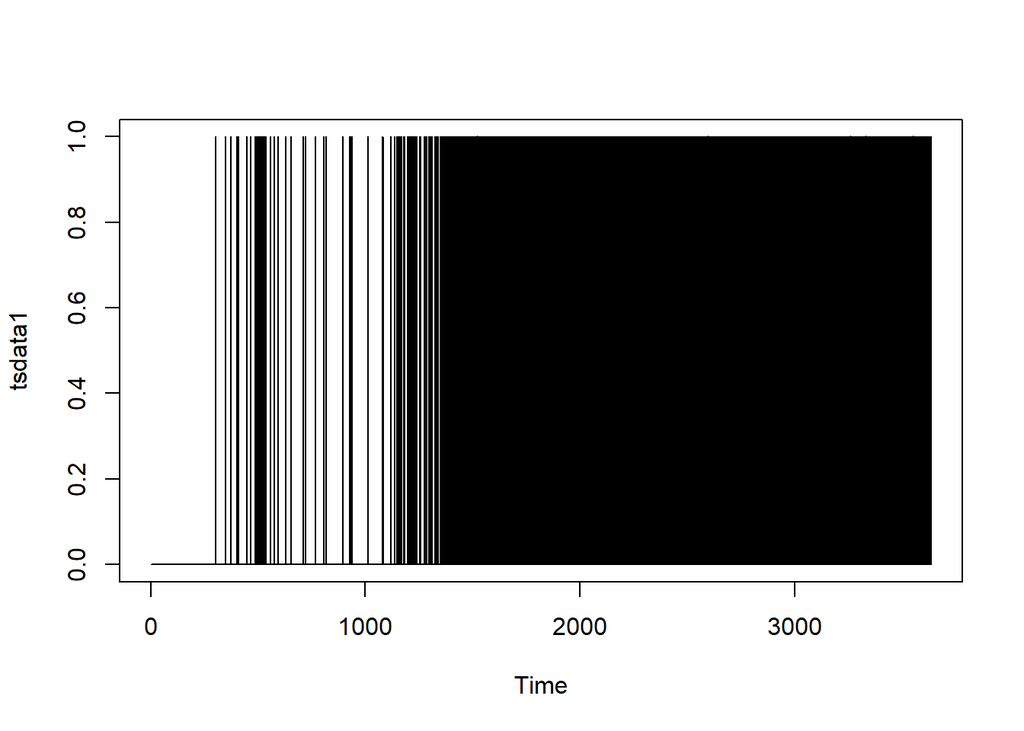

```r
tsdata1<-ts(data$suicide,frequency=50,start = c(1,1))
plot(tsdata1)
```

```r
am<-auto.arima(tsdata1)
f2<-forecast(am,h=4)
f2
```

```
##          Point Forecast      Lo 80     Hi 80      Lo 95     Hi 95
## 3634.820   1.564493e-53 -0.2514688 0.2514688 -0.3845884 0.3845884
## 3634.840   1.397479e-53 -0.2608121 0.2608121 -0.3988776 0.3988776
## 3634.860   1.589190e-53 -0.2672977 0.2672977 -0.4087965 0.4087965
## 3634.880   1.524551e-53 -0.2746158 0.2746158 -0.4199886 0.4199886
```

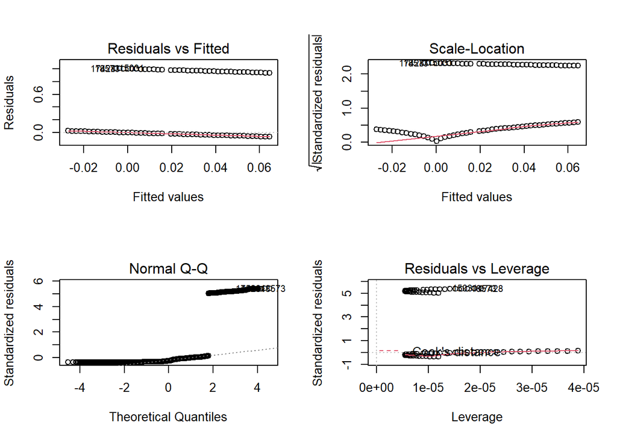

```r
layout(matrix(1:4,2,2))
plot(lm(data$suicide~data$iyear))
```

### aggregate the cycles and display a year on year trend.

```r
t = aggregate(tsData,FUN=mean)
t
```

```
## Time Series:
## Start = 2011
## End = 5504
## Frequency = 1
##    [1]         NA         NA  0.1153846         NA         NA         NA
##    [7]         NA         NA         NA         NA         NA         NA
##   [13]         NA         NA         NA         NA         NA         NA
##   [19]         NA         NA         NA         NA         NA         NA
##   [25]         NA         NA         NA         NA  0.8076923  0.2115385
##   [31]         NA         NA         NA         NA         NA         NA
##   [37]         NA         NA         NA         NA         NA         NA
##   [43]         NA         NA         NA         NA         NA         NA
##   [49]         NA         NA         NA         NA         NA         NA
##   [55]         NA         NA         NA         NA         NA         NA
##   [61]         NA         NA         NA         NA         NA         NA
```

[output cut: 572 more lines]

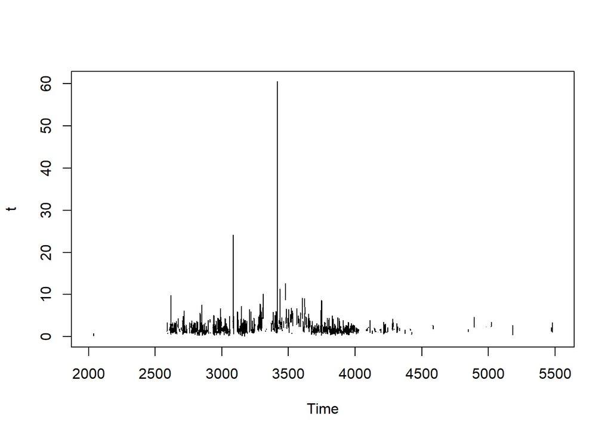

```r
plot(t)
```

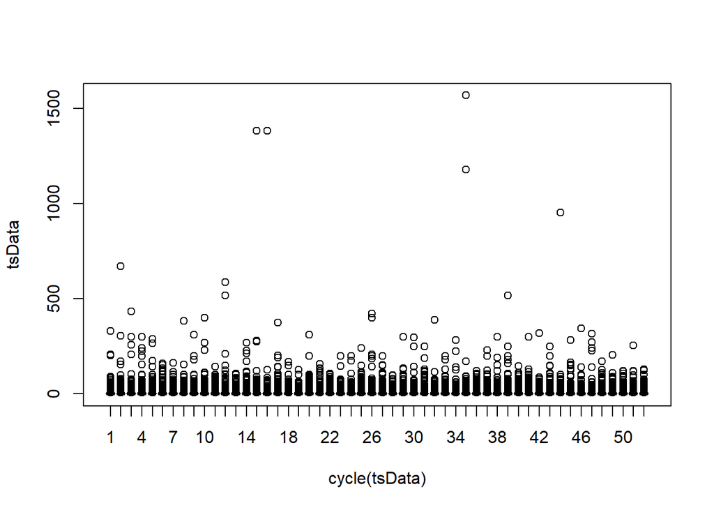

```r
boxplot(tsData ~ cycle(tsData))
```

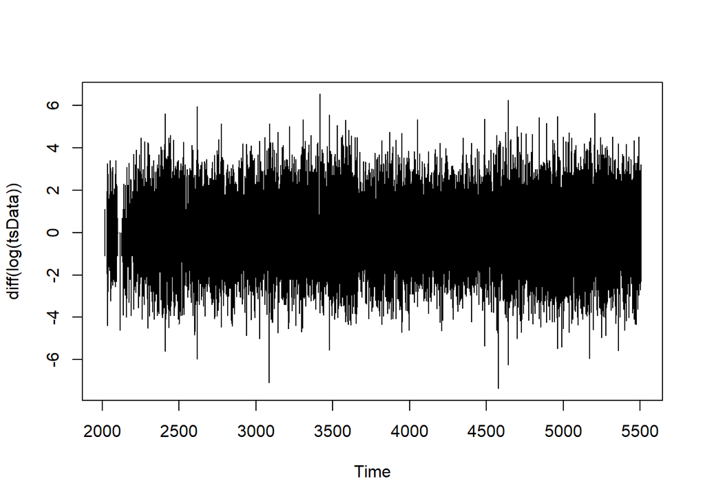

```r
plot(diff(log(tsData)))
```

```r
autoArimaModel = auto.arima(tsData, d = 1)
autoArimaModel
```

```
## Series: tsData
## ARIMA(5,1,0)
##
## Coefficients:
##           ar1      ar2      ar3      ar4      ar5
##       -0.7122  -0.5679  -0.4324  -0.2966  -0.1609
## s.e.   0.0025   0.0029   0.0030   0.0029   0.0024
##
## sigma^2 estimated as 149.6:  log likelihood=-673102.3
## AIC=1346217   AICc=1346217   BIC=1346277
```

##predict and test

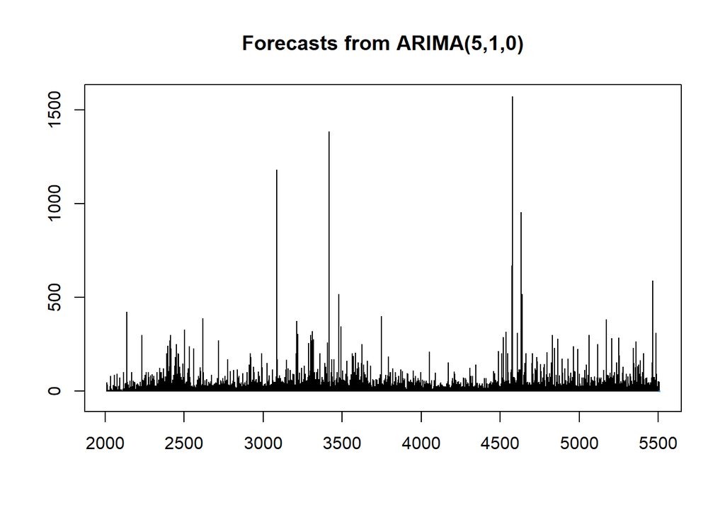

```r
autoPred = forecast(autoArimaModel, h=25)
plot(autoPred)
```

## Inference:

1. We first loaded dataset,create timseries data,build forecast plot for arima-model.
2. We then build arima-model ,used Acf and pacf method and finally see accuracy of our model.

```r
print(Sys.time())
```

```
## [1] "2021-12-12 14:34:59 IST"
```

```r
print(Sys.getenv("COMPUTERNAME"))
```

```
## [1] "DESKTOP-81LB2RD"
```

```r
print(Sys.getenv("USERNAME"))
```

```
## [1] "User"
```